# APSTA-GE 2003: Intermediate Quantitative Methods

22 September 2020

## Reminders

- Assignment 1
  - Due: **09/23/2020 11:55pm (EST)**
- Assignment 2 is available now
  - Due: **10/02/2020 11:55pm (EST)**
- Office hours
  - Monday 9 - 10am (EST)
  - Wednesday 12:30 - 1:30pm (EST)
- Office hour notes
  - Available on NYU Classes under the “Resources” tab

## Fun slide

**“Get ten bagels when you arrive at the bakery. If you see muffins, get one.”**

How many bagels will you buy?

- A. 10
- B. 1

## Another fun slide

**“Get ten bagels when you arrive at the bakery. If you see muffins, get one.”**

```r
has_Muffin <- TRUE
shopping_at <- function (location) {
  if (location == "bakery") {
    if (has_Muffin == TRUE) {
      bagel <- 1
    } else {
      bagel <- 10
    }
  }
  return(bagel)
}
shopping_at(location = "bakery")
```

```
## [1] 1
```

## One more fun slide

```r
has_Muffin <- TRUE
shopping_at <- function (human = TRUE, location) {
  if (location == "bakery") {
    if (human == TRUE) {
      if (has_Muffin == TRUE) {
        bagel <- 10
        muffin <- 1
      } else {
        bagel <- 10
      }
    } else {
      if (has_Muffin == TRUE) {
        bagel <- 1
      } else {
        bagel <- 10
      }
    }
  }
  return(bagel)
}
shopping_at(human = TRUE, location = "bakery")  # 10
shopping_at(human = FALSE, location = "bakery") # 1
```

## How about another fun slide?

To make things right, try to talk like this:

When you arrive at the bakery:

- If there are muffins, buy 1 muffin and 10 bagels. Checkout.
- If there is no muffin, buy 10 bagels. Checkout.

## So many fun slides

How we communicate:

- "Get some bagels. Maybe we should get some muffins. I don’t know. If muffins look good, get some. Oh! Don’t forget brownies. If you buy all three, get less bagels cause that will be too much.

Human: totally fine! don’t worry I got it!

Computer:

- error: “some” is not defined
- logic error: “maybe”
- logic error: “I don’t know, either.”
- error: “good” is not defined
- error: “less” is not defined
- logic warning: “If you buy all three…”

## Today’s topics

- Math Review
  - Ordinary Least Squares Linear Regression
- Programming in R
  - Simple regression analysis from scratch

## Math Review

## Linear Regression

There are many types of regression analysis.

In this course, we will focus on linear regression.

\[ Y_i = \beta_0 + \beta_1 \times X_i + \varepsilon \] where \(\beta_0\) is the intercept, \(\beta_1\) is the slope, and \(\varepsilon\) is the error.

## We need some data

Let’s create 100 data points with two variables: `X` and `Y`, which are highly correlated.

\[ Y_i = X_i + \varepsilon \]

```
##          X        Y       Diff.
## 1 20.38640 21.90553  1.51912916
## 2 19.38370 19.35558 -0.02812049
## 3 21.16075 23.04652  1.88576877
## 4 20.51952 20.76465  0.24513554
## 5 17.96081 18.43433  0.47352225
## 6 19.97013 19.32663 -0.64350365
```

## Let’s visualize the simulated data set

```r
p <- ggplot(dat_sim, aes(x = X, y = Y)) +
  geom_point() +
  theme_minimal()
ggplotly(p)
```

[interactive chart not shown]

```r
paste("Correlation Coefficient: ",
      round(cor(x = dat_sim$X, y = dat_sim$Y), digits = 3),
      sep = "")
```

```
## [1] "Correlation Coefficient: 0.901"
```

## We need a model

Let’s fit a linear regression model. A linear regression defines a line:

\[ \hat{Y} = \beta_0 + \beta_1 X_i \]

[interactive chart not shown]

## What does this mean?

**Regression line** is the line that minimizes the **squared distances/errors** between \(Y_i\) and the line. In this case:

\[ (\beta_0, \beta_1) = \mathcal{argmin} \sum_{i=1}^{100} (Y_i - \hat {Y_i})^2 = \mathcal{argmin} \sum_{i=1}^{100} (Y_i - (\beta_0 + \beta_1 X_i))^2 \]

[interactive chart not shown]

## We love math!

\[ \begin{align} \mathcal{Q}(\beta_0, \beta_1) & = \sum_{i=1}^{n} (Y_i - \hat {Y_i})^2 = \sum_{i=1}^{n} (Y_i - (\beta_0 + \beta_1 X_i))^2 \\ & = \sum_{i=1}^n (Y_i - \beta_0 -\beta_1 X_i)^2 \\ & = \sum_{i=1}^n Y_{i}^2 + n \beta_0^2 + \beta_1^2 \sum_{i=1}^n X_i^2 - 2 \beta_0 \sum_{i=1}^n Y_i - 2 \beta_1 \sum_{i=1}^n Y_i X_i + 2 \beta_0 \beta_1 \sum_{i=1}^n X_i \\ \end{align} \]

## We love math so much!

\[ \mathcal{Q}(\beta_0, \beta_1) = \sum_{i=1}^n Y_{i}^2 + n \beta_0^2 + \beta_1^2 \sum_{i=1}^n X_i^2 - 2 \beta_0 \sum_{i=1}^n Y_i - 2 \beta_1 \sum_{i=1}^n Y_i X_i + 2 \beta_0 \beta_1 \sum_{i=1}^n X_i \]

\[ \frac{\partial Q}{\partial \beta_0} = 2n\beta_0 - 2n\overline{Y} + 2n\beta_1 \overline{X} \]

\[ \frac{\partial Q}{\partial \beta_1} = 2\beta_1 \sum_{i=1}^n X_i^2 + 2n\beta_0 \overline{X} - 2n\sum_{i=1}^n Y_i X_i \]

where \(\overline{Y}\) is the mean of \(Y\), and \(\overline{X}\) is the mean of \(X\).

## We love math! (Yes we do!)

\(\frac{\partial \mathcal{Q}}{\partial \beta_0}\) is the change of line equation if its intercept (\(\beta_0\)) is varied and its slope (\(\beta_1\)) is kept constant.

\(\frac{\partial \mathcal{Q}}{\partial \beta_1}\) is the change of line equation if its slope (\(\beta_1\)) is varied and its intercept (\(\beta_0\)) is kept constant.

## Almost there …

To get the Ordinary **Least** Squares (OLS), we need to make sure there is no freedom of movement. This means, check if the second derivatives are positive.

\[ \frac{\partial \mathcal{Q}}{\partial \beta_0} = 2n \beta_0 - 2n \overline{Y} + 2n \beta_1 \overline{X} \]

\[ \frac{\partial \mathcal{Q}}{\partial \beta_0^2} = 2n \]

\[ \frac{\partial \mathcal{Q}}{\partial \beta_1} = 2 \beta_1 \sum_{i=1}^n X_i^2 + 2n \beta_0 \overline{X} - 2n \sum_{i=1}^n Y_i X_i \]

\[ \frac{\partial \mathcal{Q}}{\partial \beta_1^2} = 2 \sum_{i=1}^n X_i^2 \]

\[ \frac{\partial \mathcal{Q}}{\partial \beta_0 \beta_1} = 2 \sum_{i=1}^n X_i = 2n \overline{X} \]

## Final math slide I promise

Then, solve \(\frac{\partial \mathcal{Q}}{\partial \beta_0}\) and \(\frac{\partial \mathcal{Q}}{\partial \beta_1}\). We can get:

\[ \frac{\partial Q}{\partial \beta_0} = 2n\beta_0 - 2n\overline{Y} + 2n\beta_1 \overline{X} \]

\[ \frac{\partial Q}{\partial \beta_1} = 2\beta_1 \sum_{i=1}^n X_i^2 + 2n\beta_0 \overline{X} - 2n\sum_{i=1}^n Y_i X_i \]

\[ \beta_0 = \overline{Y} - \beta_1 \overline{X} \]

\[ \beta_1 = \frac{\sum_{i=1}^n (X_i - \overline{X})(Y_i - \overline{Y})} {\sum_{i=1}^n (X_i - \overline{X})^2} = \frac{\sum_{i=1}^n (X_i - \overline{X})(Y_i - \overline{Y})} {n \times Var.(X_i)} = \frac{Corr.(X, Y) \times S.D.(Y)}{S.D.(X)} \] The higher the correlation, the higher the slope.

## Correlation and slope

[interactive chart not shown]

## Programming in R

## Getting the data set

[2017 Cherry Blossom Run Data, 2017](https://www.openintro.org/data/index.php?data=run17)

[Download Here](https://www.openintro.org/data/csv/run17.csv)

Available on NYU Classes under the “Resources - Tong’s Lab - Lab 3”

## The Data Set

Number of rows: 19,961

Variables

- bib: number on the runner’s bib (ID)
- name: initials
- sex: biological sex
- age
- city: home city
- net_sec: time record in seconds (accounting for staggered starting time)
- clock_sec: time record in seconds (based on the clock)
- pace_sec: average time per mile, in seconds
- event: either the “10 Mile” race or the “5K”

## Import the data set to RStudio

```r
# Set working directory

# Load the data set
dat <- read.csv("run17.csv")
```

## Check dimensions

```
## [1] 19961
```

## Descriptive Analysis

## Hypotheses

\(H_0\): For 10 Mile race, the mean of the net finish time of male runners is the same as female runners.

\(H_1\): For 10 Mile race, the mean of the net finish time of male runners is **not** the same as female runners.

## Subset the data set

```r
dat_10m <- dat[dat$even == "10 Mile", ]
dat_10m$sex <- ifelse(dat_10m$sex == "M", 1, 0)
```

## Levene’s test

To examine if pooled variance is suitable.

```r
leveneTest(net_sec ~ factor(sex), data = dat_10m)
```

```
## Levene's Test for Homogeneity of Variance (center = median)
##          Df F value    Pr(>F)
## group     1  34.267 4.891e-09 ***
##       17440
## ---
## Signif. codes:  0 '***' 0.001 '**' 0.01 '*' 0.05 '.' 0.1 ' ' 1
```

## T-test

```r
t.test(net_sec ~ sex, data = dat_10m, var.equal = FALSE)
```

```
##
##  Welch Two Sample t-test
##
## data:  net_sec by sex
## t = 40.434, df = 14287, p-value < 2.2e-16
## alternative hypothesis: true difference in means is not equal to 0
## 95 percent confidence interval:
##  582.1310 641.4466
## sample estimates:
## mean in group 0 mean in group 1
##        6113.618        5501.829
```

## Linear regression

```r
summary(lm(net_sec ~ sex, data = dat_10m))
```

```
##
## Call:
## lm(formula = net_sec ~ sex, data = dat_10m)
##
## Residuals:
##      Min       1Q   Median       3Q      Max
## -2896.62  -687.62   -38.62   640.33  2896.17
##
## Coefficients:
##             Estimate Std. Error t value Pr(>|t|)
## (Intercept) 6113.618      9.454  646.69   <2e-16 ***
## sex         -611.789     14.927  -40.98   <2e-16 ***
## ---
## Signif. codes:  0 '***' 0.001 '**' 0.01 '*' 0.05 '.' 0.1 ' ' 1
##
## Residual standard error: 966.2 on 17440 degrees of freedom
## Multiple R-squared:  0.08786,    Adjusted R-squared:  0.0878
## F-statistic:  1680 on 1 and 17440 DF,  p-value: < 2.2e-16
```

## Visualize regression results

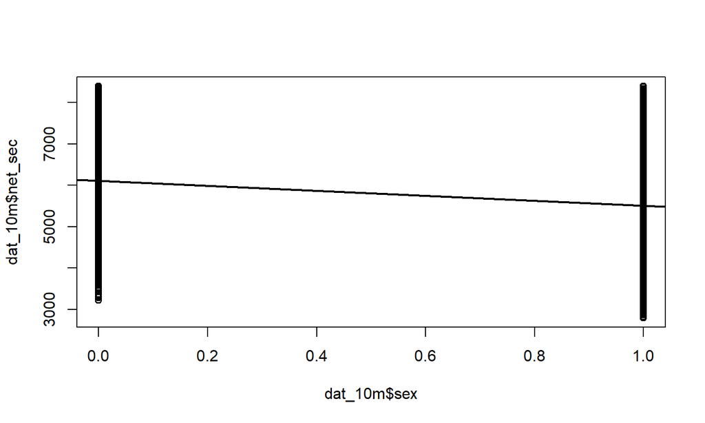

```r
plot(x = dat_10m$sex, y = dat_10m$net_sec, type = "p")
abline(a = 6113.618, b = -611.789, lwd = 2)
```

## Let’s do another regression analysis

On average, the older, the slower.

```r
summary(lm2 <- lm(net_sec ~ age, data = dat_10m))
```

```
##
## Call:
## lm(formula = net_sec ~ age, data = dat_10m)
##
## Residuals:
##      Min       1Q   Median       3Q      Max
## -2969.38  -700.70   -20.42   672.78  2670.51
##
## Coefficients:
##              Estimate Std. Error t value Pr(>|t|)
## (Intercept) 5388.0324    27.2989  197.37   <2e-16 ***
## age           12.9782     0.7087   18.31   <2e-16 ***
## ---
## Signif. codes:  0 '***' 0.001 '**' 0.01 '*' 0.05 '.' 0.1 ' ' 1
##
## Residual standard error: 1002 on 17440 degrees of freedom
## Multiple R-squared:  0.01886,    Adjusted R-squared:  0.01881
## F-statistic: 335.3 on 1 and 17440 DF,  p-value: < 2.2e-16
```

## Visualize regression results

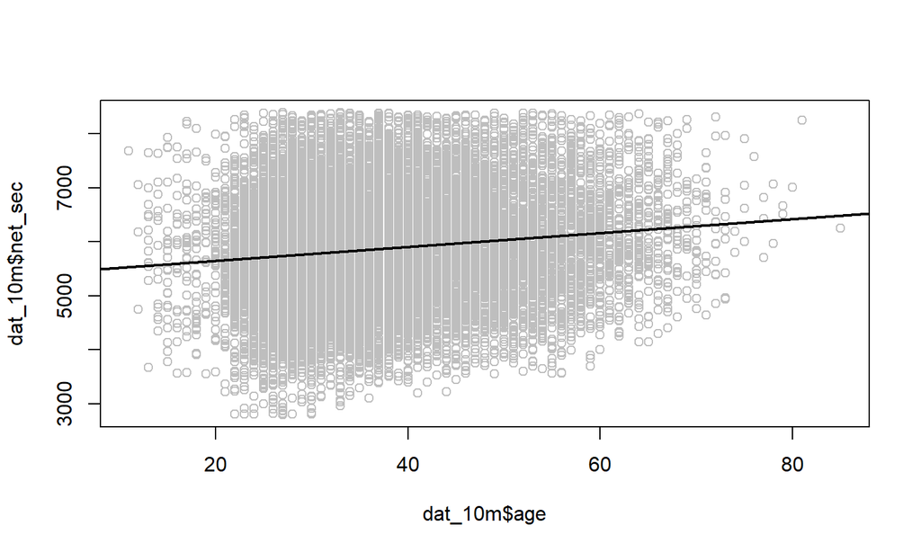

```r
plot(x = dat_10m$age, y = dat_10m$net_sec, type = "p", col = "grey")
abline(a = 5388.0324, b = 12.9782, lwd = 2)
```

## De-mean

```r
dat_10m$age0 <- dat_10m$age - mean(dat_10m$age)
summary(lm3 <- lm(net_sec ~ age0, data = dat_10m))
```

```
##
## Call:
## lm(formula = net_sec ~ age0, data = dat_10m)
##
## Residuals:
##      Min       1Q   Median       3Q      Max
## -2969.38  -700.70   -20.42   672.78  2670.51
##
## Coefficients:
##              Estimate Std. Error t value Pr(>|t|)
## (Intercept) 5868.2292     7.5877  773.38   <2e-16 ***
## age0          12.9782     0.7087   18.31   <2e-16 ***
## ---
## Signif. codes:  0 '***' 0.001 '**' 0.01 '*' 0.05 '.' 0.1 ' ' 1
##
## Residual standard error: 1002 on 17440 degrees of freedom
## Multiple R-squared:  0.01886,    Adjusted R-squared:  0.01881
## F-statistic: 335.3 on 1 and 17440 DF,  p-value: < 2.2e-16
```

## Visualize regression results

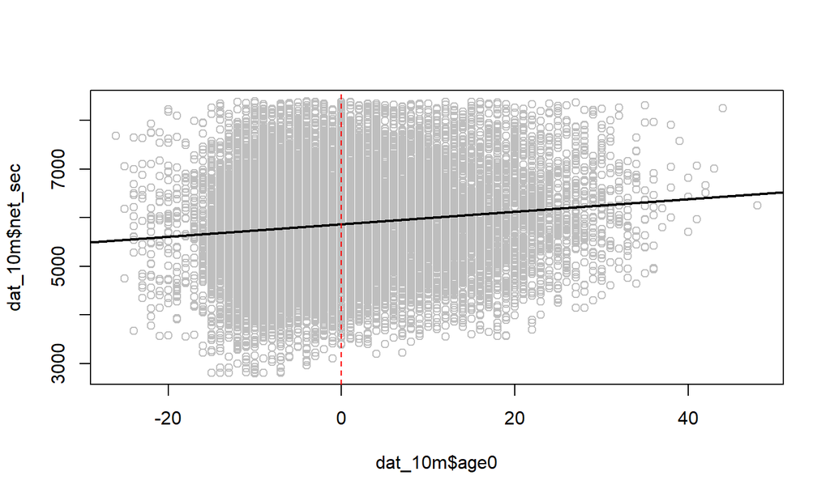

```r
plot(x = dat_10m$age0, y = dat_10m$net_sec, type = "p", col = "grey")
abline(a = 5868.2292, b = 12.9782, lwd = 2)
abline(v = 0, lty = "dashed", col = "red")
```

## Standardize

```r
dat_10m$age1 <- dat_10m$age0 / sd(dat_10m$age0)
summary(lm4 <- lm(net_sec ~ age1, data = dat_10m))
```

```
##
## Call:
## lm(formula = net_sec ~ age1, data = dat_10m)
##
## Residuals:
##      Min       1Q   Median       3Q      Max
## -2969.38  -700.70   -20.42   672.78  2670.51
##
## Coefficients:
##             Estimate Std. Error t value Pr(>|t|)
## (Intercept) 5868.229      7.588  773.38   <2e-16 ***
## age1         138.950      7.588   18.31   <2e-16 ***
## ---
## Signif. codes:  0 '***' 0.001 '**' 0.01 '*' 0.05 '.' 0.1 ' ' 1
##
## Residual standard error: 1002 on 17440 degrees of freedom
## Multiple R-squared:  0.01886,    Adjusted R-squared:  0.01881
## F-statistic: 335.3 on 1 and 17440 DF,  p-value: < 2.2e-16
```

## Visualize regression results

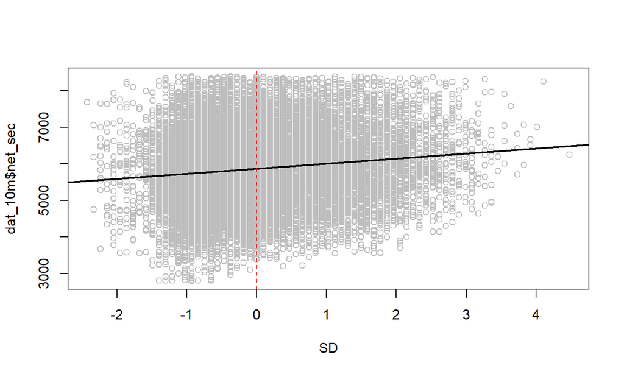

```r
plot(x = dat_10m$age1, y = dat_10m$net_sec, type = "p", col = "grey", xlab = "SD")
abline(a = 5868.229, b = 138.950, lwd = 2)
abline(v = 0, lty = "dashed", col = "red")
```